# Assignment 3

Author

Haoyu Yu

# Text Mining

## 1.Tokenize the abstracts and count the number of each token. Do you see anything interesting? Does removing stop words change what tokens appear as the most frequent? What are the 5 most common tokens for each search term after removing stopwords?

```r
library(dplyr)
library(readr)
library(tidytext)
library(ggplot2)
pub <- read.csv("pubmed.csv")
tokens <- pub %>%
  unnest_tokens(word, abstract) %>%
  count(term, word, sort = TRUE)
head(tokens)
```

```
          term  word    n
1        covid   the 9741
2        covid    of 7668
3        covid covid 7275
4 preeclampsia   the 7119
5        covid    19 7035
6        covid   and 6861
```

```r
data("stop_words")
tokens_cleaned <- pub %>%
  unnest_tokens(word, abstract) %>%
  anti_join(stop_words, by = "word") %>%
  count(term, word, sort = TRUE)
head(tokens_cleaned)
```

```
             term     word    n
1           covid    covid 7275
2           covid       19 7035
3 prostate cancer   cancer 3840
4 prostate cancer prostate 3832
5           covid patients 2293
6    preeclampsia      pre 2038
```

Before removing stop words, The most frequently occurring words are “the”, “of”, “covid”, and “the”. Most of these words are stop words, which are not helpful for analyzing the text. After removing the stop words, the situation has changed a lot. The most frequent words have become “covid”, “19”, “cancer”, and “prostate”, which are useful to help us analyzing the text.

The 5 most common tokens for each search term after removing stopwords.

```r
top_words <- tokens_cleaned %>%
  group_by(term) %>%
  slice_max(n, n = 5)
print(top_words, n = 30)
```

```
# A tibble: 25 × 3
# Groups:   term [5]
   term            word             n
   <chr>           <chr>        <int>
 1 covid           covid         7275
 2 covid           19            7035
 3 covid           patients      2293
 4 covid           disease        943
 5 covid           pandemic       800
 6 cystic fibrosis fibrosis       867
 7 cystic fibrosis cystic         862
 8 cystic fibrosis cf             625
 9 cystic fibrosis patients       586
10 cystic fibrosis disease        400
11 meningitis      patients       446
12 meningitis      meningitis     429
13 meningitis      meningeal      219
14 meningitis      csf            206
15 meningitis      clinical       187
16 preeclampsia    pre           2038
17 preeclampsia    eclampsia     2005
18 preeclampsia    preeclampsia  1863
19 preeclampsia    women         1196
20 preeclampsia    pregnancy      969
21 prostate cancer cancer        3840
22 prostate cancer prostate      3832
23 prostate cancer patients       934
24 prostate cancer treatment      926
25 prostate cancer disease        652
```

## 2.Tokenize the abstracts into bigrams. Find the 10 most common bigrams and visualize them with ggplot2.

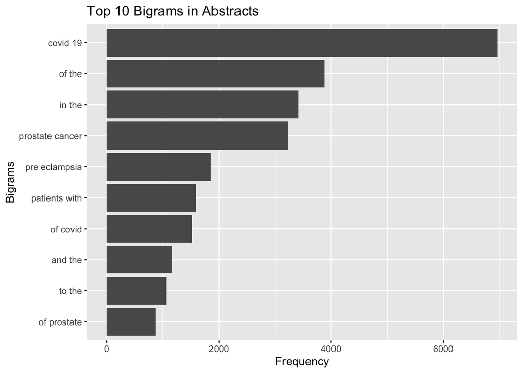

```r
bigrams <- pub %>%
  unnest_tokens(bigram, abstract, token = "ngrams", n = 2) %>%
  count(bigram, sort = TRUE)
top_bigrams <- bigrams %>% slice_max(n, n = 10)
ggplot(top_bigrams, aes(x = reorder(bigram, n), y = n)) +
  geom_col() +
  coord_flip() +
  labs(title = "Top 10 Bigrams in Abstracts", x = "Bigrams", y = "Frequency")
```

## 3.Calculate the TF-IDF value for each word-search term combination (here you want the search term to be the “document”). What are the 5 tokens from each search term with the highest TF-IDF value? How are the results different from the answers you got in question 1?

```r
tf_idf_tokens <- tokens %>%
  bind_tf_idf(word, term, n) %>%
  arrange(term, desc(tf_idf))
top_tf_idf_words <- tf_idf_tokens %>%
  group_by(term) %>%
  slice_max(tf_idf, n = 5)
print(top_tf_idf_words, n=30)
```

```
# A tibble: 25 × 6
# Groups:   term [5]
   term            word                n      tf   idf  tf_idf
   <chr>           <chr>           <int>   <dbl> <dbl>   <dbl>
 1 covid           covid            7275 0.0371  1.61  0.0597
 2 covid           pandemic          800 0.00408 1.61  0.00657
 3 covid           coronavirus       647 0.00330 1.61  0.00531
 4 covid           sars              372 0.00190 1.61  0.00305
 5 covid           cov               334 0.00170 1.61  0.00274
 6 cystic fibrosis cf                625 0.0127  0.916 0.0117
 7 cystic fibrosis fibrosis          867 0.0176  0.511 0.00901
 8 cystic fibrosis cystic            862 0.0175  0.511 0.00896
 9 cystic fibrosis cftr               86 0.00175 1.61  0.00282
10 cystic fibrosis sweat              83 0.00169 1.61  0.00272
11 meningitis      meningitis        429 0.00919 1.61  0.0148
12 meningitis      meningeal         219 0.00469 1.61  0.00755
13 meningitis      pachymeningitis   149 0.00319 1.61  0.00514
14 meningitis      csf               206 0.00441 0.916 0.00405
15 meningitis      meninges          106 0.00227 1.61  0.00366
16 preeclampsia    eclampsia        2005 0.0143  1.61  0.0230
17 preeclampsia    preeclampsia     1863 0.0133  1.61  0.0214
18 preeclampsia    pregnancy         969 0.00690 0.511 0.00353
19 preeclampsia    maternal          797 0.00568 0.511 0.00290
20 preeclampsia    gestational       191 0.00136 1.61  0.00219
21 prostate cancer prostate         3832 0.0312  1.61  0.0502
22 prostate cancer androgen          305 0.00248 1.61  0.00400
23 prostate cancer psa               282 0.00230 1.61  0.00369
24 prostate cancer prostatectomy     215 0.00175 1.61  0.00282
25 prostate cancer castration        148 0.00120 1.61  0.00194
```

For term “cystic fibrosis”, the 5 most common tokens are “fibrosis”, “cystic”, “cf”, “patients”, “disease”. The 5 highest TF-IDF values remain “fibrosis”, “cystic” and “cf”, but got other two different words, “cftr” and “sweat”.

For term “meningitis”, the 5 most common tokens are “patients”, “meningitis”, “meningeal”, “csf”, “clinical”. The 5 highest TF-IDF values remain “meningitis”, “meningeal” and “csf”, but got other two different words, “pachymeningitis” and “meninges”.

For term “preeclampsia”, the 5 most common tokens are “pre”, “eclampsia”, “preeclampsia”, “women”, “pregnancy”. The 5 highest TF-IDF values remain “eclampsia”, “preeclampsia” and “pregnancy”, but got other two different words, “maternal” and “gestational”.

For term “prostate cancer”, the 5 most common tokens are “cancer”, “prostate”, “patients”, “treatment”, “disease”. The 5 highest TF-IDF values just remain “prostate”, but got other four different words, “androgen”, “psa”, “prostatectomy” and “castration”.

Some results have changed, and more professional words have appeared in the 5 highest TF-IDF values.

# Sentiment Analysis

## 1.Perform a sentiment analysis using the NRC lexicon. What is the most common sentiment for each search term? What if you remove “positive” and “negative” from the list?

```r
library(textdata)
nrc_lexicon <- get_sentiments("nrc")
sentiments_nrc <- pub %>%
  unnest_tokens(word, abstract) %>%
  inner_join(nrc_lexicon, by = "word") %>%
  count(term, sentiment, sort = TRUE)
most_common_sentiments <- sentiments_nrc %>%
  group_by(term) %>%
  slice_max(n, n = 1)
most_common_sentiments
```

```
# A tibble: 5 × 3
# Groups:   term [5]
  term            sentiment     n
  <chr>           <chr>     <int>
1 covid           positive   9874
2 cystic fibrosis positive   2747
3 meningitis      negative   2109
4 preeclampsia    positive   8014
5 prostate cancer negative   8918
```

```r
sentiments_nrc_filtered <- sentiments_nrc %>%
  filter(!sentiment %in% c("positive", "negative"))
most_common_sentiments_filtered <- sentiments_nrc_filtered %>%
  group_by(term) %>%
  slice_max(n, n = 1)
most_common_sentiments_filtered
```

```
# A tibble: 5 × 3
# Groups:   term [5]
  term            sentiment        n
  <chr>           <chr>        <int>
1 covid           fear          7730
2 cystic fibrosis disgust       1714
3 meningitis      fear          1510
4 preeclampsia    anticipation  4780
5 prostate cancer fear          8118
```

Positive is the most common sentiment for “covid”, “cystic fibrosis” and “preeclampsia”. Negative is the most common sentiment for “meningitis” and “prostate cancer”.

After removing positive and negative, fear is the most common sentiment for “covid”, “meningitis” and “prostate cancer”. Disgust is the most common sentiment for “cystic fibrosis”. Anticipation is the most common sentiment for “preeclampsia”.

## 2.Now perform a sentiment analysis using the AFINN lexicon to get an average positivity score for each abstract (hint: you may want to create a variable that indexes, or counts, the abstracts). Create a visualization that shows these scores grouped by search term. Are any search terms noticeably different from the others?

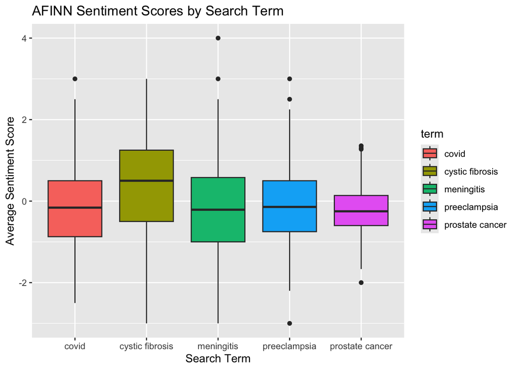

```r
afinn_lexicon <- get_sentiments("afinn")
afinn_scores <- pub %>%
  mutate(abstract_id = row_number()) %>%
  unnest_tokens(word, abstract) %>%
  inner_join(afinn_lexicon, by = "word") %>%
  group_by(term, abstract_id) %>%
  summarise(avg_score = mean(value, na.rm = TRUE), .groups = "drop")
ggplot(afinn_scores, aes(x = factor(term), y = avg_score, fill = term)) +
  geom_boxplot() +
  labs(title = "AFINN Sentiment Scores by Search Term", x = "Search Term", y = "Average Sentiment Score")
```

The score of “cystic fibrosis” is different from others. It is the only term with a positive average sentiment score, which between 0 and 1. Other scores are between 0 and -1.